# **Desafio de Ciencia de Dados da Gerdau - Data & Analytics**

[figure not shown]

## **Introdução**

O time de Data Science da Gerdau usa Inteligência Artificial e Advanced Analytics para resolver problemas diversos dentro da nossa empresa. Nesse desafio você terá contato com algumas das tarefas diárias de um Cientista de Dados do time e como ele avaliaremos, como suas competências estão conectadas com nossos pilares técnicos e do negócio.

Guiaremos você ao longo do problema, e sua senioridade, de acordo com nossos padrões e pilares, será definida pela maneira como você resolverá cada item.

### **O que você deve levar em consideração**

- Descrever a abordagem utilizada na resolução do desafio
- Trechos de códigos deverão ter comentários essenciais
- O desafio deverá ser feito com a linguagem de programação Python + bibliotecas que você achar necessário
- Soluções utilizando Excel, R e outras linguagens serão desconsideradas
- Recomendamos utilizar Jupyter Lab ou Notebook.

### **Prazo de entrega**

- De acordo conforme combinado com o time de Data & Analytics

### **Desclassificação Automática**

- Entregar fora do prazo
- Compartilhar sua solução com outras pessoas
- Compartilhar sua solução em repositórios públicos. Exemplo: GitHub

### **Objetivo**

A produção de uma empresa de aço envolve a fabricação de vários tipos de componentes, incluindo bobinas e placas. As informações sobre o consumo de energia são registradas em um sistema de armazenamento em nuvem. O monitoramento do consumo energético desta indústria está disponível nos dados fornecidos. Desta forma, **gostariamos que você preveja o consumo elétrico em uma perspectiva mensal**.

## 0. Tratamento dos Dados

Apesar dos dados recebidos ja foram entregues tratados, pessoalmente gosto de dar uma explorada inicial e converter o tipo dos dados para otimização do espaço de memória.

```python
import numpy as np
import pandas as pd
```

```python
df = pd.read_csv('../datasets/raw.csv')
df.head()
```

|  | Data | Energia_usada | V1 | V2 | V3 | V4 | V5 | V6 | V7 | V8 | V9 |
| --- | --- | --- | --- | --- | --- | --- | --- | --- | --- | --- | --- |
| 0 | 01/01/2018 00:15 | 3.17 | 2.95 | 0.0 | 0.0 | 73.21 | 100.0 | 900 | Dia da Semana | Segunda-feira | Carga leve |
| 1 | 01/01/2018 00:30 | 4.00 | 4.46 | 0.0 | 0.0 | 66.77 | 100.0 | 1800 | Dia da Semana | Segunda-feira | Carga leve |
| 2 | 01/01/2018 00:45 | 3.24 | 3.28 | 0.0 | 0.0 | 70.28 | 100.0 | 2700 | Dia da Semana | Segunda-feira | Carga leve |
| 3 | 01/01/2018 01:00 | 3.31 | 3.56 | 0.0 | 0.0 | 68.09 | 100.0 | 3600 | Dia da Semana | Segunda-feira | Carga leve |
| 4 | 01/01/2018 01:15 | 3.82 | 4.50 | 0.0 | 0.0 | 64.72 | 100.0 | 4500 | Dia da Semana | Segunda-feira | Carga leve |

```python
df.columns = ['data', 'consumo_energia', 'corrente_atrasada', 'corrente_principal', 'co2', 'potencia_atrasado', 'potencia_principal', 'segundos_depois_meia_noite', 'estado_semana', 'dia_semana', 'tipo_carga']
```

```python
memory_before = df.memory_usage(deep=True).sum()
memory_before
```

```
11722932
```

```python
df.info(memory_usage='deep')
```

```
<class 'pandas.core.frame.DataFrame'>
RangeIndex: 35040 entries, 0 to 35039
Data columns (total 11 columns):
 #   Column                      Non-Null Count  Dtype
---  ------                      --------------  -----
 0   data                        35040 non-null  object
 1   consumo_energia             35040 non-null  float64
 2   corrente_atrasada           35040 non-null  float64
 3   corrente_principal          35040 non-null  float64
 4   co2                         35040 non-null  float64
 5   potencia_atrasado           35040 non-null  float64
 6   potencia_principal          35040 non-null  float64
 7   segundos_depois_meia_noite  35040 non-null  int64
 8   estado_semana               35040 non-null  object
 9   dia_semana                  35040 non-null  object
 10  tipo_carga                  35040 non-null  object
dtypes: float64(6), int64(1), object(4)
memory usage: 11.2 MB
```

```python
df.nunique()
```

```
data                          35040
consumo_energia                3343
corrente_atrasada              1954
corrente_principal              768
co2                               8
potencia_atrasado              5079
potencia_principal             3366
segundos_depois_meia_noite       96
estado_semana                     2
dia_semana                        7
tipo_carga                        3
dtype: int64
```

```python
df.data = df.data.astype('datetime64[ns]')
df.co2 = df.co2.astype('float16')
df.segundos_depois_meia_noite = df.segundos_depois_meia_noite.astype('int32')
df.estado_semana = df.estado_semana.astype('category')
df.dia_semana = df.dia_semana.astype('category')
df.tipo_carga = df.tipo_carga.astype('category')
```

```python
memory_after = df.memory_usage(deep=True).sum()
memory_after
```

```
1998745
```

```python
df.info(memory_usage='deep')
```

```
<class 'pandas.core.frame.DataFrame'>
RangeIndex: 35040 entries, 0 to 35039
Data columns (total 11 columns):
 #   Column                      Non-Null Count  Dtype
---  ------                      --------------  -----
 0   data                        35040 non-null  datetime64[ns]
 1   consumo_energia             35040 non-null  float64
 2   corrente_atrasada           35040 non-null  float64
 3   corrente_principal          35040 non-null  float64
 4   co2                         35040 non-null  float16
 5   potencia_atrasado           35040 non-null  float64
 6   potencia_principal          35040 non-null  float64
 7   segundos_depois_meia_noite  35040 non-null  int32
 8   estado_semana               35040 non-null  category
 9   dia_semana                  35040 non-null  category
 10  tipo_carga                  35040 non-null  category
dtypes: category(3), datetime64[ns](1), float16(1), float64(5), int32(1)
memory usage: 1.9 MB
```

```python
print (f'{memory_after/memory_before*100: .2f}% da memória original')
```

```
 17.05% da memória original
```

```python
df.to_pickle('../datasets/processed.pkl')
```

## 1. Análise Exploratória e Qualidade dos Dados

Gostariamos que nesta primeira etapa do processo, use sua curiosidade e criatividade, além de experiência, para extrair informação de cada variável ou relação entre as variáveis do dataset. Nesta etapa, podem surgir insights que gerem valor para o negócio, além de ajudar ao entendimento do problema. Esperamos que você gere estatísticas, gráficos, visualizações que descrevam os dados e como eles estão conectados com o problema.

Temos acesso aos dados de consumo elétrico da empresa, referentes a um período de 1 ano, sendo que a medição é realizada em intervalos de 15 minutos.

| Nome | Description. | Tipo Variável |
| --- | --- | --- |
| Data | Data de registro do consumo | Continua |
| Energia_usada | Consumo de energia da empresa [kWh] | Continua |
| V1 | Corrente atrasada [kVarh] | Continua |
| V2 | Corrente principal [kVarh] | Continua |
| V3 | Medições de C02 [ppm] | Continua |
| V4 | Fator de potência atual atrasado | Continua |
| V5 | Fator de potência atual principal | Continua |
| V6 | Número de segundos a partir da meia-noite [S] | Continua |
| V7 | Estado da semana (Final de semana ou dia da semana) | Categorica |
| V8 | Dia da semana (Terça-feira, Sábado, etc) | Categorica |
| V9 | Tipo de carga (Carga leve, Carga média, Carga máxima) | Categorica |

### Imports

```python
import numpy as np
import pandas as pd
import matplotlib.pyplot as plt
import seaborn as sns
from statsmodels.tsa.seasonal import seasonal_decompose

sns.set(style='darkgrid')
palette = 'mako'
sns.set_theme(style="ticks", rc={"axes.spines.right": False, "axes.spines.top": False})
```

### Análise inicial

#### Visão inicial dos dados

```python
df = pd.read_pickle('../datasets/processed.pkl')
df.head()
```

|  | data | consumo_energia | corrente_atrasada | corrente_principal | co2 | potencia_atrasado | potencia_principal | segundos_depois_meia_noite | estado_semana | dia_semana | tipo_carga |
| --- | --- | --- | --- | --- | --- | --- | --- | --- | --- | --- | --- |
| 0 | 2018-01-01 00:15:00 | 3.17 | 2.95 | 0.0 | 0.0 | 73.21 | 100.0 | 900 | Dia da Semana | Segunda-feira | Carga leve |
| 1 | 2018-01-01 00:30:00 | 4.00 | 4.46 | 0.0 | 0.0 | 66.77 | 100.0 | 1800 | Dia da Semana | Segunda-feira | Carga leve |
| 2 | 2018-01-01 00:45:00 | 3.24 | 3.28 | 0.0 | 0.0 | 70.28 | 100.0 | 2700 | Dia da Semana | Segunda-feira | Carga leve |
| 3 | 2018-01-01 01:00:00 | 3.31 | 3.56 | 0.0 | 0.0 | 68.09 | 100.0 | 3600 | Dia da Semana | Segunda-feira | Carga leve |
| 4 | 2018-01-01 01:15:00 | 3.82 | 4.50 | 0.0 | 0.0 | 64.72 | 100.0 | 4500 | Dia da Semana | Segunda-feira | Carga leve |

```python
df.info()
```

```
<class 'pandas.core.frame.DataFrame'>
RangeIndex: 35040 entries, 0 to 35039
Data columns (total 11 columns):
 #   Column                      Non-Null Count  Dtype
---  ------                      --------------  -----
 0   data                        35040 non-null  datetime64[ns]
 1   consumo_energia             35040 non-null  float64
 2   corrente_atrasada           35040 non-null  float64
 3   corrente_principal          35040 non-null  float64
 4   co2                         35040 non-null  float16
 5   potencia_atrasado           35040 non-null  float64
 6   potencia_principal          35040 non-null  float64
 7   segundos_depois_meia_noite  35040 non-null  int32
 8   estado_semana               35040 non-null  category
 9   dia_semana                  35040 non-null  category
 10  tipo_carga                  35040 non-null  category
dtypes: category(3), datetime64[ns](1), float16(1), float64(5), int32(1)
memory usage: 1.9 MB
```

Observação dos dados numéricos

Foram desconsideradas as variáveis referente a data e segundos depois da meia noite, por serem medidas de tempo

```python
df.drop(columns=['data', 'segundos_depois_meia_noite']).describe().T.drop('count', axis=1)
```

|  | mean | std | min | 25% | 50% | 75% | max |
| --- | --- | --- | --- | --- | --- | --- | --- |
| consumo_energia | 27.386892 | 33.444380 | 0.0 | 3.20 | 4.57 | 51.237500 | 157.180000 |
| corrente_atrasada | 13.035384 | 16.306000 | 0.0 | 2.30 | 5.00 | 22.640000 | 96.910000 |
| corrente_principal | 3.870949 | 7.424463 | 0.0 | 0.00 | 0.00 | 2.090000 | 27.760000 |
| co2 | 0.011520 | 0.016144 | 0.0 | 0.00 | 0.00 | 0.020004 | 0.070007 |
| potencia_atrasado | 80.578056 | 18.921322 | 0.0 | 63.32 | 87.96 | 99.022500 | 100.000000 |
| potencia_principal | 84.367870 | 30.456535 | 0.0 | 99.70 | 100.00 | 100.000000 | 100.000000 |

Observação dos dados categóricos

```python
df.describe(exclude=[np.number, np.datetime64]).T.drop('count', axis=1)
```

|  | unique | top | freq |
| --- | --- | --- | --- |
| estado_semana | 2 | Dia da Semana | 25056 |
| dia_semana | 7 | Segunda-feira | 5088 |
| tipo_carga | 3 | Carga leve | 18072 |

```python
df.nunique()
```

```
data                          35040
consumo_energia                3343
corrente_atrasada              1954
corrente_principal              768
co2                               8
potencia_atrasado              5079
potencia_principal             3366
segundos_depois_meia_noite       96
estado_semana                     2
dia_semana                        7
tipo_carga                        3
dtype: int64
```

#### A partir do site do governo foi adquirido as datas referentes as estações do ano

- [Verão: 21 dezembro, às (14h28) de 2017 a 20 de março de 2018 (13h14);](https://www.gov.br/observatorio/pt-br/assuntos/noticias/verao-2017-comeca-no-dia-21-de-dezembro-as-14h28)
- [Verão: de 21 de dezembro (20h22) a 20 de março de 2019 (18h58);](https://www.gov.br/observatorio/pt-br/assuntos/noticias/verao-2018)
- [Outono: de 20 de março (13h14) a 21 de junho de 2018 (7h07);](https://www.gov.br/observatorio/pt-br/assuntos/noticias/outono-2018-comeca-no-proximo-dia-20)
- [Inverno: de 21 de junho (7h07) a 22 de setembro de 2018 (22h53);](https://www.gov.br/observatorio/pt-br/assuntos/noticias/solsticio-inverno-2018)
- [Primavera: de 22 de setembro (22h53) a 21 de dezembro de 2018 (20h22).](https://www.gov.br/observatorio/pt-br/assuntos/noticias/primavera-2018)

```python
def estacao_do_ano(data):
    verao_2018_inicio = pd.Timestamp('2017-12-21 14:28:00')
    verao_2018_fim = pd.Timestamp('2018-03-20 13:14:00')
    verao_2019_inicio = pd.Timestamp('2018-12-21 20:22:00')
    verao_2019_fim = pd.Timestamp('2019-03-20 18:58:00')
    outono_inicio = pd.Timestamp('2018-03-20 13:14:00')
    outono_fim = pd.Timestamp('2018-06-21 07:07:00')
    inverno_inicio = pd.Timestamp('2018-06-21 07:07:00')
    inverno_fim = pd.Timestamp('2018-09-22 22:53:00')
    primavera_inicio = pd.Timestamp('2018-09-22 22:53:00')
    primavera_fim = pd.Timestamp('2018-12-21 20:22:00')

    if verao_2018_inicio <= data < verao_2018_fim or verao_2019_inicio <= data < verao_2019_fim:
        return 'Verão'
    elif outono_inicio <= data < outono_fim:
        return 'Outono'
    elif inverno_inicio <= data < inverno_fim:
        return 'Inverno'
    elif primavera_inicio <= data < primavera_fim:
        return 'Primavera'
    else:
        return 'Fora do intervalo'

df['estacao'] = df['data'].apply(estacao_do_ano)
del estacao_do_ano
```

#### Observação da variável target em ordem crescente e decrescente

Apesar dos dados não possuirem valores null, foi observado uma linha completamente nula, podendo ser considerado um outlier, ou um erro na medição

```python
df.sort_values('consumo_energia', ascending=True).head(10)
```

|  | data | consumo_energia | corrente_atrasada | corrente_principal | co2 | potencia_atrasado | potencia_principal | segundos_depois_meia_noite | estado_semana | dia_semana | tipo_carga | estacao |
| --- | --- | --- | --- | --- | --- | --- | --- | --- | --- | --- | --- | --- |
| 29855 | 2018-07-11 00:00:00 | 0.00 | 0.00 | 0.0 | 0.0 | 0.00 | 0.0 | 0 | Dia da Semana | Quarta-feira | Carga leve | Inverno |
| 25848 | 2018-09-27 06:15:00 | 2.45 | 4.93 | 0.0 | 0.0 | 44.50 | 100.0 | 22500 | Dia da Semana | Quinta-feira | Carga leve | Primavera |
| 25847 | 2018-09-27 06:00:00 | 2.45 | 4.97 | 0.0 | 0.0 | 44.22 | 100.0 | 21600 | Dia da Semana | Quinta-feira | Carga leve | Primavera |
| 26234 | 2018-01-10 06:45:00 | 2.45 | 4.36 | 0.0 | 0.0 | 48.99 | 100.0 | 24300 | Dia da Semana | Segunda-feira | Carga leve | Verão |
| 25851 | 2018-09-27 07:00:00 | 2.45 | 5.08 | 0.0 | 0.0 | 43.44 | 100.0 | 25200 | Dia da Semana | Quinta-feira | Carga leve | Primavera |
| 26018 | 2018-09-29 00:45:00 | 2.45 | 4.00 | 0.0 | 0.0 | 52.23 | 100.0 | 2700 | Final de Semana | Sabado | Carga leve | Primavera |
| 25820 | 2018-09-26 23:15:00 | 2.45 | 4.64 | 0.0 | 0.0 | 46.69 | 100.0 | 83700 | Dia da Semana | Quarta-feira | Carga leve | Primavera |
| 25822 | 2018-09-26 23:45:00 | 2.45 | 4.61 | 0.0 | 0.0 | 46.93 | 100.0 | 85500 | Dia da Semana | Quarta-feira | Carga leve | Primavera |
| 25821 | 2018-09-26 23:30:00 | 2.45 | 4.61 | 0.0 | 0.0 | 46.93 | 100.0 | 84600 | Dia da Semana | Quarta-feira | Carga leve | Primavera |
| 23733 | 2018-05-09 05:30:00 | 2.48 | 5.00 | 0.0 | 0.0 | 44.43 | 100.0 | 19800 | Dia da Semana | Quarta-feira | Carga leve | Outono |

```python
df.sort_values('consumo_energia', ascending=False).head(10)
```

|  | data | consumo_energia | corrente_atrasada | corrente_principal | co2 | potencia_atrasado | potencia_principal | segundos_depois_meia_noite | estado_semana | dia_semana | tipo_carga | estacao |
| --- | --- | --- | --- | --- | --- | --- | --- | --- | --- | --- | --- | --- |
| 31238 | 2018-11-22 09:45:00 | 157.18 | 77.72 | 0.0 | 0.070007 | 89.64 | 100.0 | 35100 | Dia da Semana | Quinta-feira | Carga media | Primavera |
| 1398 | 2018-01-15 13:45:00 | 153.14 | 70.45 | 0.0 | 0.070007 | 90.85 | 100.0 | 49500 | Dia da Semana | Segunda-feira | Carga media | Verão |
| 31723 | 2018-11-27 11:00:00 | 151.67 | 69.73 | 0.0 | 0.070007 | 90.86 | 100.0 | 39600 | Dia da Semana | Terca-feira | Carga maxima | Primavera |
| 7812 | 2018-03-23 09:15:00 | 151.31 | 65.20 | 0.0 | 0.070007 | 91.84 | 100.0 | 33300 | Dia da Semana | Sexta-feira | Carga media | Outono |
| 1701 | 2018-01-18 17:30:00 | 149.65 | 64.87 | 0.0 | 0.070007 | 91.75 | 100.0 | 63000 | Dia da Semana | Quinta-feira | Carga maxima | Verão |
| 33848 | 2018-12-19 14:15:00 | 149.18 | 74.56 | 0.0 | 0.070007 | 89.45 | 100.0 | 51300 | Dia da Semana | Quarta-feira | Carga media | Primavera |
| 162 | 2018-02-01 16:45:00 | 147.46 | 65.27 | 0.0 | 0.000000 | 91.44 | 100.0 | 60300 | Dia da Semana | Terca-feira | Carga media | Verão |
| 6111 | 2018-05-03 16:00:00 | 146.88 | 70.49 | 0.0 | 0.070007 | 90.16 | 100.0 | 57600 | Dia da Semana | Segunda-feira | Carga maxima | Outono |
| 1679 | 2018-01-18 12:00:00 | 146.48 | 84.89 | 0.0 | 0.070007 | 86.52 | 100.0 | 43200 | Dia da Semana | Quinta-feira | Carga maxima | Verão |
| 447 | 2018-05-01 16:00:00 | 146.34 | 66.92 | 0.0 | 0.070007 | 90.94 | 100.0 | 57600 | Dia da Semana | Sexta-feira | Carga media | Outono |

#### Análise referente aos meses

```python
def get_mode(x: pd.Series) -> str:
    return x.mode()[0]

df_groupby_month = df.groupby(df.data.dt.month_name(), sort=False).agg(
    {
        'consumo_energia': ['mean', 'median'],
        'corrente_atrasada': ['mean', 'median'],
        'corrente_principal': ['mean', 'median'],
        'co2': ['mean', 'median'],
        'potencia_atrasado': ['mean', 'median'],
        'potencia_principal': ['mean', 'median'],
        'dia_semana': get_mode,
        'tipo_carga': get_mode,
    }
)

del get_mode

df_groupby_month
```

| data | consumo_energia mean | consumo_energia median | corrente_atrasada mean | corrente_atrasada median | corrente_principal mean | corrente_principal median | co2 mean | co2 median | potencia_atrasado mean | potencia_atrasado median | potencia_principal mean | potencia_principal median | dia_semana get_mode | tipo_carga get_mode |
| --- | --- | --- | --- | --- | --- | --- | --- | --- | --- | --- | --- | --- | --- | --- |
| January | 33.876300 | 13.68 | 15.136035 | 5.18 | 4.520719 | 0.00 | 0.014759 | 0.010002 | 85.030961 | 90.010 | 84.085104 | 100.0 | Domingo | Carga leve |
| February | 29.330588 | 5.15 | 12.377035 | 4.86 | 4.434911 | 0.00 | 0.011741 | 0.000000 | 83.319107 | 89.740 | 82.301150 | 100.0 | Sexta-feira | Carga leve |
| March | 27.107282 | 4.46 | 11.852571 | 4.57 | 3.993380 | 0.00 | 0.011476 | 0.000000 | 81.274617 | 88.640 | 85.479073 | 100.0 | Sabado | Carga leve |
| April | 25.923153 | 4.12 | 12.074792 | 4.28 | 4.427858 | 0.00 | 0.010879 | 0.000000 | 81.075212 | 87.690 | 83.314701 | 100.0 | Domingo | Carga leve |
| May | 28.636166 | 4.21 | 13.803901 | 5.15 | 3.579778 | 0.00 | 0.012218 | 0.000000 | 78.506962 | 86.950 | 86.133770 | 100.0 | Segunda-feira | Carga leve |
| June | 25.909760 | 4.21 | 12.484104 | 5.18 | 3.726187 | 0.00 | 0.010903 | 0.000000 | 78.559090 | 87.365 | 85.753622 | 100.0 | Quinta-feira | Carga leve |
| July | 27.497762 | 4.05 | 12.963784 | 5.08 | 3.508673 | 0.00 | 0.011698 | 0.000000 | 80.922403 | 90.175 | 83.770171 | 100.0 | Domingo | Carga leve |
| August | 28.021788 | 4.43 | 14.766176 | 5.47 | 2.888901 | 0.00 | 0.011912 | 0.000000 | 76.723044 | 86.025 | 87.687722 | 100.0 | Quinta-feira | Carga leve |
| September | 20.581271 | 3.42 | 11.048615 | 5.11 | 3.855295 | 0.00 | 0.008431 | 0.000000 | 76.982681 | 86.400 | 80.129663 | 100.0 | Sexta-feira | Carga leve |
| October | 27.564022 | 4.46 | 14.895481 | 5.98 | 3.486727 | 0.00 | 0.011573 | 0.000000 | 76.964345 | 85.605 | 85.193646 | 100.0 | Sabado | Carga leve |
| November | 30.867705 | 5.11 | 14.681601 | 5.15 | 3.175757 | 0.00 | 0.013087 | 0.000000 | 81.948656 | 87.965 | 87.589590 | 100.0 | Domingo | Carga leve |
| December | 23.312893 | 4.25 | 10.217043 | 3.31 | 4.898138 | 0.04 | 0.009550 | 0.000000 | 85.774002 | 89.655 | 80.754160 | 100.0 | Segunda-feira | Carga leve |

Apenas com esse agrupamento foi observada uma forte correlação referente ao consumo de energia e a corrente atrasada, então ordenamos os meses referentes as duas variaveis e comparamos

```python
consumo_energia = df_groupby_month.consumo_energia.sort_values('mean', ascending=False).index, df_groupby_month.consumo_energia.sort_values('median', ascending=False).index
corrente_atrasada = df_groupby_month.corrente_atrasada.sort_values('mean', ascending=False).index, df_groupby_month.corrente_atrasada.sort_values('median', ascending=False).index
```

```python
# Mean
pd.DataFrame(data=[consumo_energia[0], corrente_atrasada[0]], index=['consumo_energia', 'corrente_atrasada']).T
```

|  | consumo_energia | corrente_atrasada |
| --- | --- | --- |
| 0 | January | January |
| 1 | November | October |
| 2 | February | August |
| 3 | May | November |
| 4 | August | May |
| 5 | October | July |
| 6 | July | June |
| 7 | March | February |
| 8 | April | April |
| 9 | June | March |
| 10 | December | September |
| 11 | September | December |

```python
# Median
pd.DataFrame(data=[consumo_energia[1], corrente_atrasada[1]], index=['consumo_energia', 'corrente_atrasada']).T
```

|  | consumo_energia | corrente_atrasada |
| --- | --- | --- |
| 0 | January | October |
| 1 | February | August |
| 2 | November | January |
| 3 | March | June |
| 4 | October | May |
| 5 | August | November |
| 6 | December | September |
| 7 | May | July |
| 8 | June | February |
| 9 | April | March |
| 10 | July | April |
| 11 | September | December |

### Análise gráfica

#### Histograma

Inicialmente vamos observar o histograma desses dados, assim observando como sua distribuição se comporta.

Para tal foram desconsiderados elementos:

- categóricos
  - Estado da semana
  - Dia da semana
  - Tipo de carga
- temporais
  - Data
  - Estação
  - Segundos após a meia noite

Foi observado que apesar do seu valor flutuante a variável co2 se comporta de maneira categórica, por possuir apenas 8 elementos únicos.

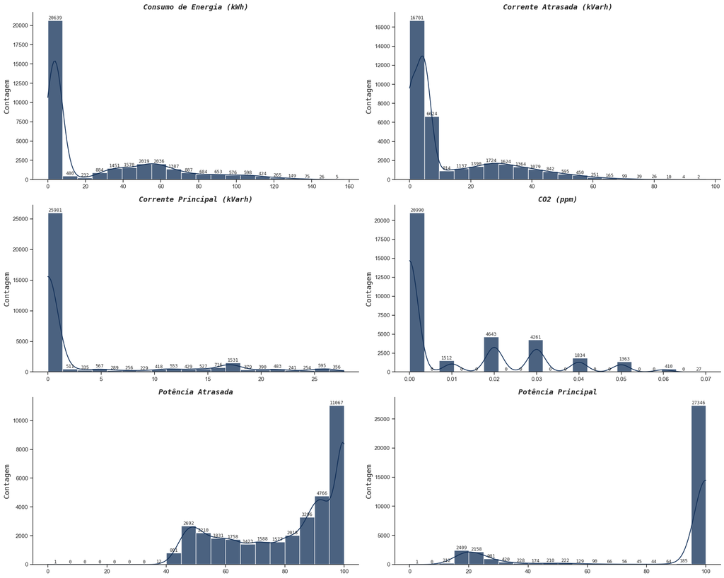

```python
def plot_histograms(df: pd.DataFrame, columns: list, n_rows: int, n_cols: int, title: list):
    fig = plt.figure(figsize=(20, 16))
    for i, column in enumerate(columns):
        ax = fig.add_subplot(n_rows, n_cols, i + 1)
        sns.histplot(data=df, x=column, ax=ax, bins=20, kde=True, color='#0f2d56', alpha=.75)
        for value in ax.containers:
            ax.bar_label(value, label_type='edge', fontsize=9, family='monospace')
        ax.set_xlabel(None)
        ax.set_ylabel('Contagem', fontsize='large', family='monospace')
        ax.set_title(title[i], fontsize='large', fontweight='bold', style='italic', family='monospace')
    fig.tight_layout()

columns = df.drop(['data', 'estado_semana', 'dia_semana', 'tipo_carga', 'estacao', 'segundos_depois_meia_noite'], axis=1).columns
title=['Consumo de Energia (kWh)', 'Corrente Atrasada (kVarh)', 'Corrente Principal (kVarh)', 'CO2 (ppm)', 'Potência Atrasada', 'Potência Principal']
plot_histograms(df=df, columns=columns, n_rows=3, n_cols=2, title=title)
plt.show()
```

#### Gráficos de Barra

Iremos agora analisar o comportamento das variáveis referentes a média de consumo energético

```python
def create_bar(df_: pd, columns: list, n_rows: int, n_cols: int, rot=45):
    y_ = 'consumo_energia'
    fig = plt.figure(figsize=(20, 30))
    for i, column in enumerate(columns):
        for j in range (0, 2):
            ax = fig.add_subplot(n_rows, n_cols, 2*i + j + 1)
            if j:
                df = df_.groupby(by=column, as_index=False, sort=False)[y_].median()
            else:
                df = df_.groupby(by=column, as_index=False, sort=False)[y_].mean()
            try:
                df[column] = df[column].str.capitalize()
            except:
                pass

            sns.barplot(data=df, x=column, y=y_, palette=palette, ax=ax)
            for value in ax.containers:
                ax.bar_label(value)
            ax.tick_params(axis='x', labelrotation=rot, size=12)
            ax.tick_params(axis='y', size=12)
            ax.set_xlabel(column.capitalize(), fontsize='large', family='monospace')
            ax.set_ylabel("Consumo de Energia (kWh)", fontsize='large', family='monospace')
            if j:
                ax.set_title(f"Mediana de Consumo de Energia por {column.capitalize()}", fontsize='large', fontweight='bold',
                             style='italic', family='monospace')
            else:
                ax.set_title(f"Média de Consumo de Energia por {column.capitalize()}", fontsize='large', fontweight='bold',
                            style='italic', family='monospace')
    fig.tight_layout()
```

Para tal observação foi considerada as variáveis categóricas

- Co2 (Por possuir comportamento categórico)
- Estação do ano
- Dia da semana
- Estado da semana
- Tipo de carga

##### Algumas observações com os gráficos de barra

##### Em ordem de plotagem

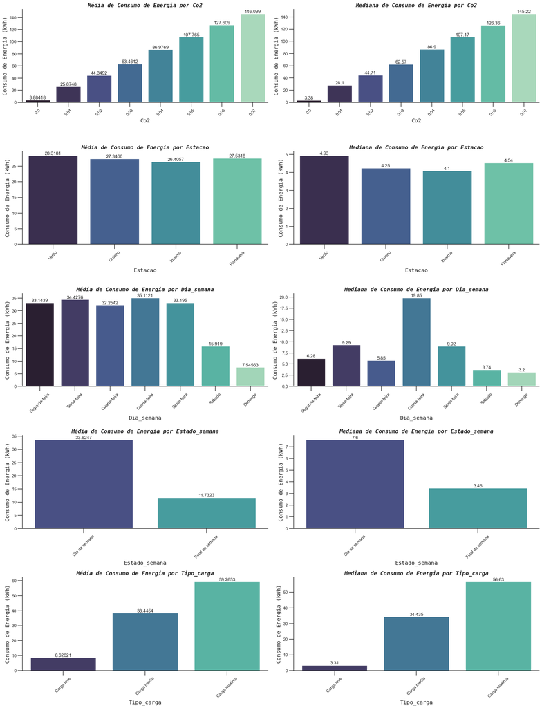

```python
columns = ['co2', 'estacao', 'dia_semana', 'estado_semana', 'tipo_carga']
create_bar(df, columns, 6, 2)
plt.show()
```

#### Gráficos de caixa

```python
def create_box_plot(df_: pd, columns: list, title: list, n_rows: int, n_cols: int):
    y_ = 'consumo_energia'
    fig = plt.figure(figsize=(20, 16))
    for i, column in enumerate(columns):
        ax = fig.add_subplot(n_rows, n_cols, i + 1)
        sns.boxplot(data=df_, x=column, y=y_, ax=ax, palette=palette)
        ax.tick_params(axis='x', size=12)
        ax.tick_params(axis='y', size=12)
        ax.set_xlabel(column.capitalize(), fontsize='large', family='monospace')
        ax.set_ylabel("Consumo de Energia (kWh)", fontsize='large', family='monospace')
        ax.set_title(f"Boxplot de Consumo de Energia por {title[i]}", fontsize='large', fontweight='bold',
                style='italic', family='monospace')
    fig.tight_layout()
```

Novamente iremos observar as variáveis categóricas

##### Algumas observações com os gráficos de caixa

Conforme aumentamos as observações temos maiores outliers, também podemos notar as diferenças entre os ranges de consumo energético.

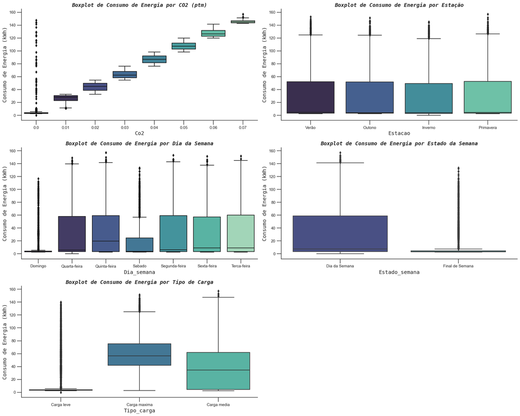

```python
columns = ['co2', 'estacao', 'dia_semana', 'estado_semana', 'tipo_carga']
title = ['CO2 (ptm)', 'Estação', 'Dia da Semana', 'Estado da Semana', 'Tipo de Carga']
create_box_plot(df, columns, title, 3, 2)
plt.show()
```

Agora iremos ver na prática a quantidade de outliers a partir do intervalo interquantil.

Nos casos analisados existe apenas outlier em um dos lados (superior ou inferior).

```python
def calculate_outliers(x: pd.Series) -> list:
    q1 = x.quantile(.25)
    q3 = x.quantile(.75)
    iqr = q3 - q1
    lower_bound = q1 - 1.5 * iqr
    upper_bound = q3 + 1.5 * iqr
    return x[(x < lower_bound)].index.tolist(), x[(x > upper_bound)].index.tolist()

for column in df.drop(['data', 'estado_semana', 'dia_semana', 'segundos_depois_meia_noite', 'tipo_carga', 'estacao'], axis=1).columns:
    lower, upper = calculate_outliers(df[column])
    column = column.replace('_', ' ')
    column = column.capitalize()
    print(f"{column}: Lower = {len(lower)}, Upper = {len(upper)}, Total = {len(lower) + len(upper)}")

del calculate_outliers
```

```
Consumo energia: Lower = 0, Upper = 328, Total = 328
Corrente atrasada: Lower = 0, Upper = 1059, Total = 1059
Corrente principal: Lower = 0, Upper = 7759, Total = 7759
Co2: Lower = 0, Upper = 437, Total = 437
Potencia atrasado: Lower = 1, Upper = 0, Total = 1
Potencia principal: Lower = 8327, Upper = 0, Total = 8327
```

```python
def calculate_amplitude(x: pd.Series) -> float:
    return x.max() - x.min()

for column in df.drop(['data', 'estado_semana', 'dia_semana', 'segundos_depois_meia_noite', 'tipo_carga', 'estacao'], axis=1).columns:
    amplitude = calculate_amplitude(df[column])
    column = column.replace('_', ' ')
    column = column.capitalize()
    print(f"{column}: Amplitude = {amplitude:.2f}")

del calculate_amplitude
```

```
Consumo energia: Amplitude = 157.18
Corrente atrasada: Amplitude = 96.91
Corrente principal: Amplitude = 27.76
Co2: Amplitude = 0.07
Potencia atrasado: Amplitude = 100.00
Potencia principal: Amplitude = 100.00
```

#### Gráfico de dispersão

##### Algumas observações

1. Confirmação da alta correlação (linear) positiva entre o consumo de energia e a corrente atrasada
2. Observada uma correlação (linear) negativa entre corrente principal e potencia principal
3. Correlação (não linear) positiva entre potencia principal e corrente atrasada

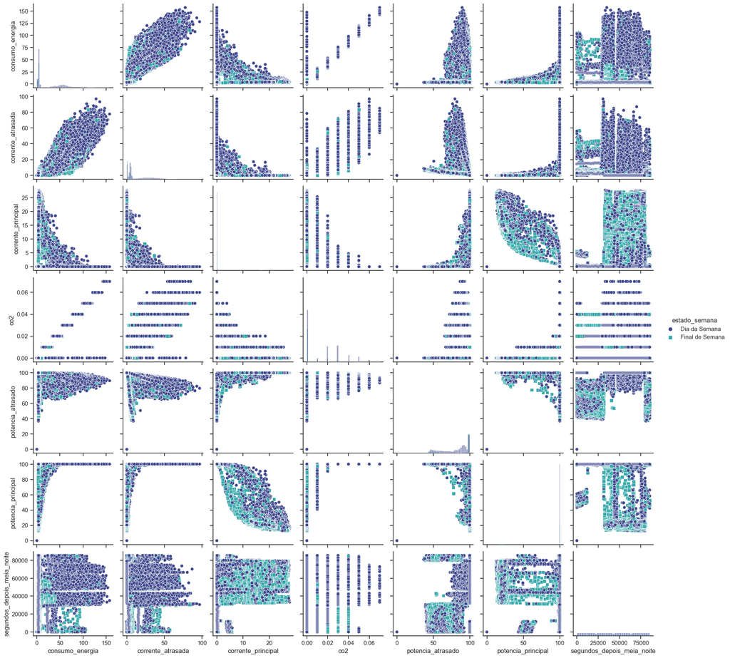

```python
sns.pairplot(df, hue="estado_semana", palette=palette, markers=["o", "s"], diag_kind="hist")
plt.show()
```

#### Matriz de correlação

Agora para confirmar as observações das correlações lineares foi plotado a matriz de correlação utilizando os três métodos:

- Pearson (linear)
- Kendall (não linear)
- Spearman (não linear)

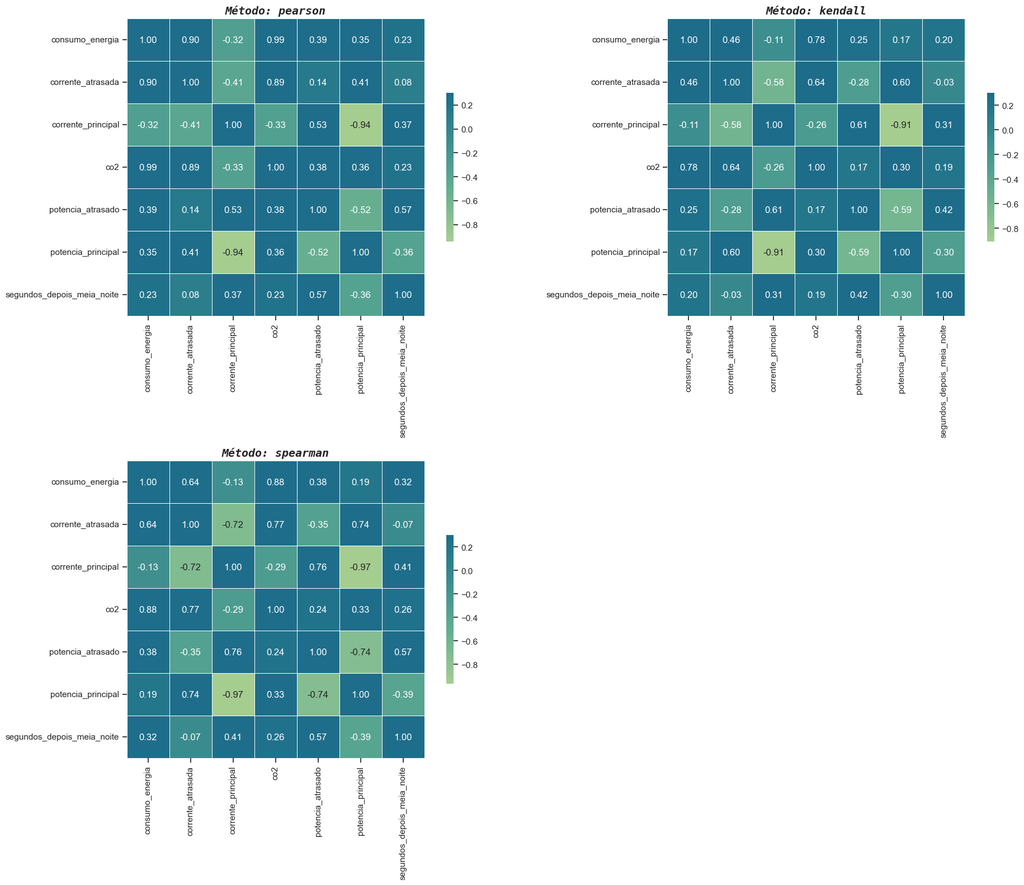

```python
fig = plt.figure(figsize=(20, 16))
for i, method in enumerate(['pearson', 'kendall', 'spearman']):
    ax = fig.add_subplot(2, 2, i + 1)
    corr = df.corr(numeric_only=True, method=method)
    sns.heatmap(corr, cmap="crest", vmax=.3, center=0,
        square=True, linewidths=.5, cbar_kws={"shrink": .5}, annot=True, fmt='.2f', ax=ax)
    ax.set_title(f'Método: {method}', fontsize='large', fontweight='bold', style='italic', family='monospace')

fig.tight_layout()

plt.show()
```

### Análise temporal

Apenas por curiosidade foi feita uma análise básica temporal

```python
df_groupby_day = df.set_index('data').resample('D').agg(
    {
        'consumo_energia': 'sum',
        'corrente_atrasada': 'sum',
        'corrente_principal': 'sum',
        'co2': 'mean',
        'potencia_atrasado': 'mean',
        'potencia_principal': 'mean',
        'dia_semana': lambda x: x.mode()[0],
        'tipo_carga': lambda x: x.mode()[0],
        'estacao': lambda x: x.mode()[0],
    }
).copy()
```

[figure not shown]

```python
plt.figure(figsize=(15, 5))

df_groupby_day['consumo_energia'].plot()
plt.xlabel('Meses')
plt.ylabel('Média de consumo de energia (kWh)')
plt.title('Quantidade de vendas por mês')
plt.show()
```

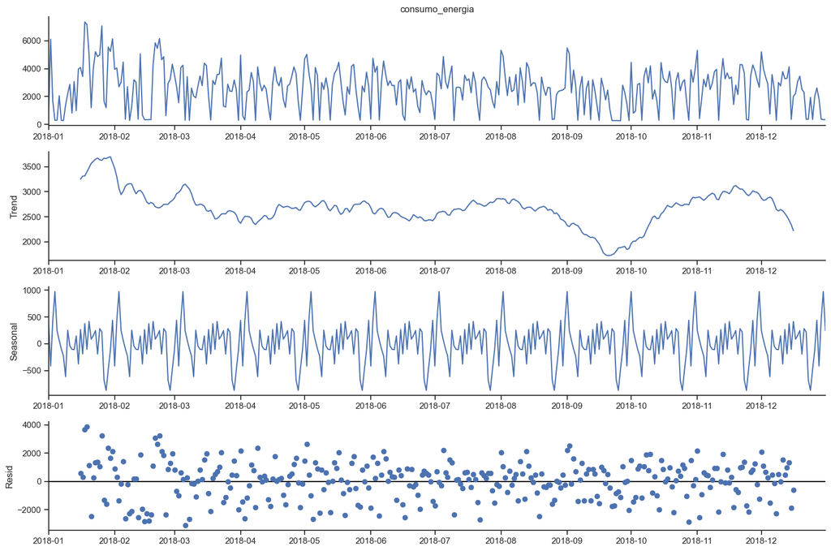

```python
decomposed = seasonal_decompose(df_groupby_day['consumo_energia'], model='additive', period=30)

fig = decomposed.plot()
fig.set_size_inches((15, 10))
fig.tight_layout()
plt.show()
```

### Conclusão do EDA

Foram realizadas diversas análises para compreender melhor a distribuição dos dados, identificar possíveis anomalias e outliers. Além disso, foram exploradas as relações entre as variáveis e como elas se correlacionam com a variável alvo.

Durante o processo de análise, foi possível identificar algumas questões importantes que precisam ser levadas em consideração durante a criação do modelo. Se duas variáveis estão altamente correlacionadas, isso pode indicar que elas estão medindo essencialmente a mesma coisa.

Correlações fortes (>=0.9)

[output not shown]

Portanto as variáveis que não possuem uma alta correlação com a variável target podem ser eliminadas para criação do modelo, deve-se entretanto observar a performance por conta do problema de multicolinearidade.

- Potência principal

Outro ponto importante é o outlier presente no index = 29855, deve-se entender o motivo de sua aparição, afinal caso o medidor esteja enviesado será necessário avaliar melhor os dados.

É importante levar em consideração todos os insights e padrões identificados, bem como as questões que precisam ser tratadas, a fim de desenvolver um modelo preciso e eficiente.

## 2. Modelo de aprendizado de máquina

Finalmente a etapa de modelagem. Mostre o processo de desenvolvimento, as técnicas utilizadas, os algoritmos, sempre justificando suas escolhas. O modelo final é aquele que você teria confiança para usar na vida real.

### 2.2 Avaliação e escolha do modelo

Descreva a(s) métrica(s) que você usou para avaliar o modelo. Lembre-se do objetivo do desafio, **Prever o consumo elétrico em uma perspectiva mensal**

## 3. Uso do modelo

Nesse ponto não há margem para mudança, é de fato o modelo final. Se bem apresentado e trazendo bons resultados, certamente o cliente da área de negócio perguntará: **"Ok, como a gente pode usar esse modelo?"** (Não precisa implementar)

1. Como será utilizado o modelo: entra base, sai status?
2. Qual é a entrega de valor deste modelo
3. Quais tecnologias você usaria
4. Como será a implementação do modelo? API, Docker, etc